# mensik_ps11

2026-01-05

# 1.

## 1a.

Regression Coeff. Estimates with Clustered Standard Errors

|  | Coefficient | Standard_Error | T_Statistic | P_Value |
| --- | --- | --- | --- | --- |
| (Intercept) | 1.5610405 | 0.1804733 | 8.6497033 | 0.0000000 |
| judge_factorHeald | -0.2380806 | 0.1409468 | -1.6891513 | 0.0920352 |
| judge_factorHugessen | -0.2580045 | 0.1414615 | -1.8238494 | 0.0689836 |
| judge_factorIacobucci | -0.4306468 | 0.1196515 | -3.5991750 | 0.0003628 |
| judge_factorMacGuigan | -0.2268063 | 0.1544218 | -1.4687447 | 0.1427540 |
| judge_factorMahoney | -0.1451685 | 0.2108267 | -0.6885680 | 0.4915278 |
| judge_factorMarceau | 0.1705660 | 0.1521120 | 1.1213189 | 0.2628813 |
| judge_factorPratte | -0.3196569 | 0.1444171 | -2.2134275 | 0.0274793 |
| judge_factorStone | -0.3087154 | 0.0965251 | -3.1982921 | 0.0015019 |
| judge_factorUrie | -0.0225033 | 0.1440480 | -0.1562206 | 0.8759445 |
| rater_factoryes | 0.2362873 | 0.0471662 | 5.0096760 | 0.0000008 |
| language_factorFrench | -0.0226542 | 0.0693149 | -0.3268303 | 0.7439815 |
| locationother | 0.1383583 | 0.0851873 | 1.6241653 | 0.1051944 |
| locationToronto | 0.1130069 | 0.0932346 | 1.2120703 | 0.2262610 |
| success | 0.2079864 | 0.0651577 | 3.1920448 | 0.0015339 |

locationToronto - holding all else constant, having a case heard or seeking refugee status in Toronto instead of Montreal is associated with a 11.3 percentage point higher probability of being granted the case compared to a case/seeking refugee status in Montreal. However this is not statistically significant.

success - holding all else constant, a one unit increase in the logit of the success rate of all cases from the refugee’s nation of origin is associated with a ~20.8 percentage point increase in the probability that a judge grants the appeal. A unit increase in logit is the natural log of the probability of a nation’s success rate – so a country with a 30% success rate’s logit would be ln(0.30/0.70) ~ -0.8. This is nonlinear, but roughly corresponds to fairly significant changes. It is statistically significant as well.

## 1b.

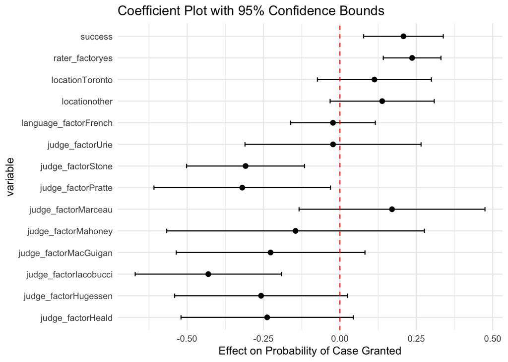

## 1c.

```
## Linear Regression
##
## 384 samples
##   5 predictor
##
## No pre-processing
## Resampling: Cross-Validated (10 fold)
## Summary of sample sizes: 345, 345, 346, 346, 346, 346, ...
## Resampling results:
##
##   RMSE       Rsquared   MAE
##   0.4127079  0.2043578  0.3463173
##
## Tuning parameter 'intercept' was held constant at a value of TRUE
```

```
##           m1_sr     m1_10f_sr
## sigma     0.4038098 0.4127079
## r.squared 0.249341  0.2043578
```

There are differences because the model is created to fit (OLS) the observed data. Held-out data doesn’t have the noise on the in sample data.

## 1d.

## 1e.

First, both models have lower $R^2$ and higher error under 10-fold cross-validation because out-of-sample tests do not “reward”the original models for being fitted to the data’s particular random noise.

Still, the fixed effects models’ higher out-of-sample $R^2$ suggests some predictive benefits to accounting for nation-level differences, and underscoring the bias-variance tradeoff. In m1, success it imposes a functional form on how ‘nation’ matters/says how a unit fares in relation to others in their country, or allows m1 control for country rates. Compared to the fixed effects model, this somewhat obscures country-level variation. The fixed effects model (nation as a factor makes each nation (except for the baseline) a parameter and gives each its own baseline), which allows the model to more/less absorb nation-level differences.

As with the tradeoff, adding country level parameters also muddy interpretability at the cross-national level, but it is in this case potentially useful (depending on your theory/aims) to see by-country variation.

# 2.

## 2a.

## 2b.

## 2c.

Including the pretest measure might be beneficial because – even though randomization balances all pre-treatment covariates in expectation – covariates might be imbalanced by chance, creating internal validity problems and inflating variance of the estimator.

the analysis involves multiple treatment arms (Basal, DRTA, Strata) across multiple outcomes, and repeated independent trials have family-wise error rates that are elevated. This increases the rate of false positives. Formal adjustments (alpha) might reduce power in this small (n = 66) sample. Moreover, since folks’ post-test scores will vary due to prior ability, and while we’re not worried about endogeneity, we can reduce residual variance assuming the control accounts for individual variability (increase the model’s explained variance/R^2).

## 2d.

First, worth flagging that 22 students per treatment group is fairly low statistical power. Second, the error rate this kind of series or “family” of tests – two different treatment contrasts per each three separate regression means 6 hypothesis tests - or the family-wise error rate is: $\leq$ 1 - (1 - 0.05)^6, or ~ 0.265. There’s a 27% probability of incorrectly rejecting a null (a Type I error). One correction would be to use a Bonferroni correction, testing hypotheses at 1-(0.95) to the (0.05/6) or 0.0085 per-test significance levels or 99.15% confidence intervals (this is the Sidak correction to make the family-wise error rate across tests 0.05).

With that said, assignment to the DRTA treatment instead of traditional teaching is associated with a statistically significant **(>0.008) effect in test 1**, where it is associated with a 3.55 higher score than traditional treatment. It also has a statistically **significant (0.003) effect in test 3,** where it is associated with 5.83 point higher scores. Assignment to the Strat treatment instead of traditional teaching has a **significant effect (0.00005) in test 2,** where it associated with 3.069 point higher scores.

At 95% intervals, the DRTA treatment has significant effects on test 3 (5.83 points) and the Strata treatment instead of traditional teaching has a significant effect on test 1 (1.9 points).

The pretest coefficient tells us that a one unit increase in pretest scores are associated with a 0.9735 point improvement in test 1 (significant with the Bonferonni correction), a 0.2987 point improvement in test 2 (significant at 95% CIs), and 0.3255 point better scores in test 3 (not significant).

This could be inferred as a suggestion that student’s performance on the first test has more to do with conditions outside of teaching method than the other tests.

## 2e.

While I can refer to max and min scores on the pre and outcome tests (1-15, 1-13, 1-57), a first mild barrier to substantive interpretation is not knowing how many points these tests are out of. It’s not that I need the scale to understand treatment effect, but rather speaking to substantive meaning of these coefficients probably requires more context of the tests and how they differ than we have here – a 2 point improvement on, for example, a 20-point total test means something different than does a 2 point improvement on a 100 point test. This is particularly true given the small sample size, where I’m confident the variance isn’t somewhat more reflective of the small sample than it is the heterogeneity of treatment effect.

If test 2 is out of 13 points (its max score), the Strata intervention also has a substantive effect, increasing scores by 23%.

However, without knowing how these tests are related to one another (or the pretest), it is difficult to speak to the substantive impact of interventions across tests, or the overall meaningfulness of these teaching interventions compared to traditional methods.

## 2f.

```
## `height` was translated to `width`.
## `height` was translated to `width`.
```

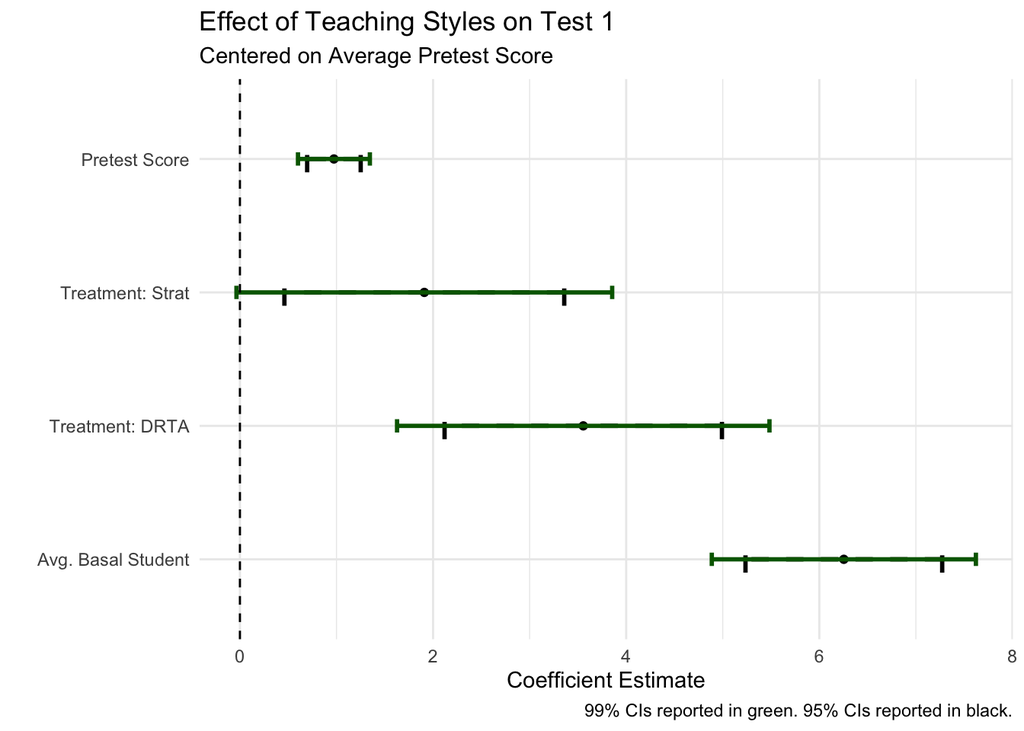

```
## `height` was translated to `width`.
## `height` was translated to `width`.
```

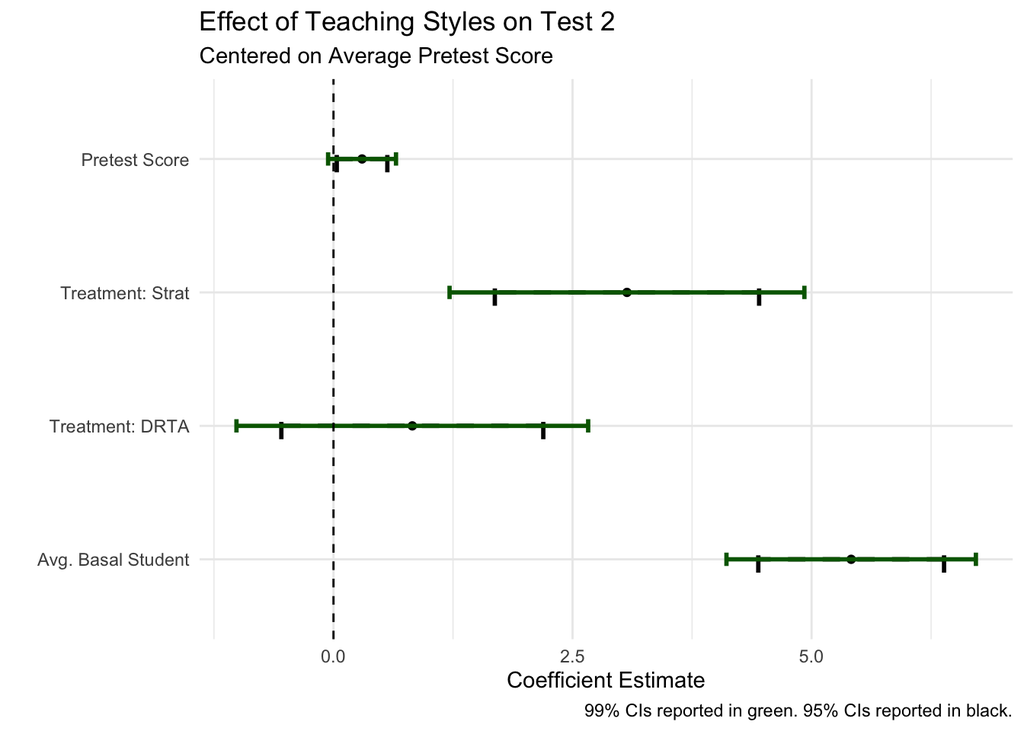

```
## `height` was translated to `width`.
## `height` was translated to `width`.
```

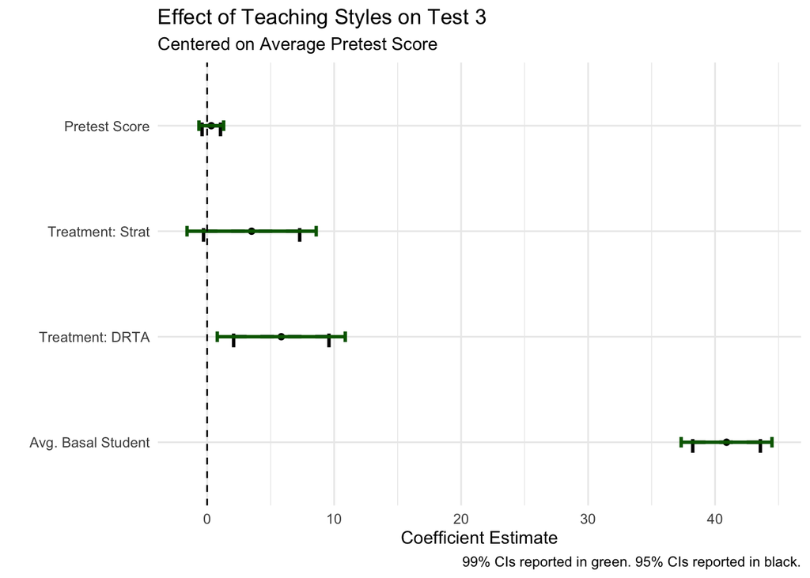